# Neural Network Framework (Keras)

## *Data Science Unit 4 Sprint 2 Assignmnet 3*

## Use the Keras Library to build a Multi-Layer Perceptron Model on the Boston Housing dataset

- The Boston Housing dataset comes with the Keras library so use Keras to import it into your notebook.
- Normalize the data (all features should have roughly the same scale)
- Import the type of model and layers that you will need from Keras.
- Instantiate a model object and use `model.add()` to add layers to your model
- Since this is a regression model you will have a single output node in the final layer.
- Use activation functions that are appropriate for this task
- Compile your model
- Fit your model and report its accuracy in terms of Mean Squared Error
- Use the history object that is returned from model.fit to make graphs of the model's loss or train/validation accuracies by epoch.
- Run this same data through a linear regression model. Which achieves higher accuracy?
- Do a little bit of feature engineering and see how that affects your neural network model. (you will need to change your model to accept more inputs)
- After feature engineering, which model sees a greater accuracy boost due to the new features?

```python
from tensorflow.keras.datasets import boston_housing
from tensorflow.keras.models import Sequential
from tensorflow.keras.layers import Dense
from tensorflow.keras.utils import normalize

from matplotlib import pyplot

from sklearn.preprocessing import MinMaxScaler
```

```python
import numpy as np
import pandas as pd
```

```python
# Loaded data
(X_train, y_train), (X_test, y_test) = boston_housing.load_data()
```

```python
X_train.shape, X_test.shape
```

```
((404, 13), (102, 13))
```

```python
X_train = X_train.reshape(404, 13)
X_test = X_test.reshape(102, 13)
```

```python
X_train = normalize(X_train, axis=-1, order=2)
X_test = normalize(X_test, axis=-1, order=2)
```

```python
# Defined model
model = Sequential()
# Add amount of neurons
# Input dimensions apply to the # of features duh
# Input
model.add(Dense(64, input_dim=13, activation='relu', name="icey_in"))
# Hidden
model.add(Dense(64, activation='relu', name="sandwich_1"))
model.add(Dense(64, activation='relu', name="sandwich_2"))
# Output
model.add(Dense(1, activation='linear', name="outtie"))
model.compile(loss='mse', optimizer='adam',
              metrics=['mae','mse','mape'])
model.summary()
```

```
Model: "sequential_38"
_________________________________________________________________
Layer (type)                 Output Shape              Param #
=================================================================
icey_in (Dense)              (None, 64)                896
_________________________________________________________________
sandwich_1 (Dense)           (None, 64)                4160
_________________________________________________________________
sandwich_2 (Dense)           (None, 64)                4160
_________________________________________________________________
outtie (Dense)               (None, 1)                 65
=================================================================
Total params: 9,281
Trainable params: 9,281
Non-trainable params: 0
_________________________________________________________________
```

```python
hist = model.fit(X_train, y_train, batch_size=32, epochs=250, validation_split=.2, verbose=False)
scores = model.evaluate(X_test, y_test, verbose=False)
```

```python
for n in range(len(model.metrics_names)):
    print(f'{model.metrics_names[n]}: {scores[n]}')
```

```
loss: 27.46843308093501
mae: 4.065676689147949
mse: 27.468433380126953
mape: 21.112960815429688
```

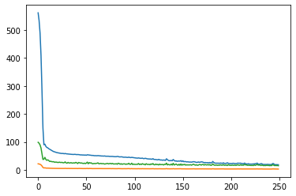

```python
pyplot.plot(hist.history['mse'])
pyplot.plot(hist.history['mae'])
pyplot.plot(hist.history['mape'])
```

### Let's do something else...

```python
from sklearn.linear_model import LinearRegression
from sklearn.metrics import mean_squared_error, r2_score
```

```python
# Loaded data
(X_train, y_train), (X_test, y_test) = boston_housing.load_data()
```

```python
X_train = X_train.reshape(404, 13)
X_test = X_test.reshape(102, 13)
```

```python
lr = LinearRegression(n_jobs=-1)
lr.fit(X_train, y_train)
y_pred = lr.predict(X_test)
mse = mean_squared_error(y_pred, y_test)
```

```python
r2_score(y_pred=y_pred, y_true=y_test)
```

```
0.7213535934621562
```

- Load and preprocess the image data similar to how we preprocessed the MNIST data in class.
- Make sure to one-hot encode your category labels
- Make sure to have your final layer have as many nodes as the number of classes that you want to predict.
- Try different hyperparameters. What is the highest accuracy that you are able to achieve.
- Use the history object that is returned from model.fit to make graphs of the model's loss or train/validation accuracies by epoch.
- Remember that neural networks fall prey to randomness so you may need to run your model multiple times (or use Cross Validation) in order to tell if a change to a hyperparameter is truly producing better results.

```python
from tensorflow.keras.models import Sequential
from tensorflow.keras.layers import Activation, Dense, Dropout
from tensorflow.keras.utils import normalize, to_categorical
from tensorflow.keras.datasets import mnist

from matplotlib import pyplot

from sklearn.preprocessing import MinMaxScaler

import numpy as np
import pandas as pd
```

```python
# Hyper Parameters
batch_size = 64
num_classes = 10
epochs = 20
```

```python
# 1. LOAD
(X_train, y_train), (X_test, y_test) = mnist.load_data()
# 2. RESHAPE
X_train = X_train.reshape(60000, 784)
X_test = X_test.reshape(10000, 784)
```

```python
# 3. ONE-HOT ENCODE
# I'm guessing this might do it? Just checked, yes it does
y_train = to_categorical(y_train, num_classes)
y_test = to_categorical(y_test, num_classes)
```

```python
mnist_m = Sequential()

# Input!
mnist_m.add(Dense(128, input_dim=784, activation='relu'))
# Hidden bois
mnist_m.add(Dense(96, activation='relu'))
mnist_m.add(Dense(96, activation='relu'))
mnist_m.add(Dense(64, activation='relu'))
mnist_m.add(Dense(64, activation='relu'))
mnist_m.add(Dense(64, activation='relu'))
mnist_m.add(Dense(64, activation='relu'))
mnist_m.add(Dense(64, activation='relu'))
mnist_m.add(Dense(144, activation='relu'))
# Outie
mnist_m.add(Dense(10, activation='softmax'))
```

```python
# Compile
mnist_m.compile(loss='categorical_crossentropy',
                optimizer='adam',
               metrics=['accuracy'])
mnist_m.summary()
```

```
Model: "sequential_16"
_________________________________________________________________
Layer (type)                 Output Shape              Param #
=================================================================
dense_111 (Dense)            (None, 128)               100480
_________________________________________________________________
dense_112 (Dense)            (None, 96)                12384
_________________________________________________________________
dense_113 (Dense)            (None, 96)                9312
_________________________________________________________________
dense_114 (Dense)            (None, 64)                6208
_________________________________________________________________
dense_115 (Dense)            (None, 64)                4160
_________________________________________________________________
dense_116 (Dense)            (None, 64)                4160
_________________________________________________________________
dense_117 (Dense)            (None, 64)                4160
_________________________________________________________________
dense_118 (Dense)            (None, 64)                4160
_________________________________________________________________
dense_119 (Dense)            (None, 144)               9360
_________________________________________________________________
dense_120 (Dense)            (None, 10)                1450
=================================================================
Total params: 155,834
Trainable params: 155,834
Non-trainable params: 0
_________________________________________________________________
```

```python
h = mnist_m.fit(X_train, y_train, batch_size=56, epochs=75, verbose=False)
scr = mnist_m.evaluate(X_test, y_test, verbose=False)
```

```python
print(f'{mnist_m.metrics_names[1]}: {scr[1]*100}')
```

```
accuracy: 97.93999791145325
```

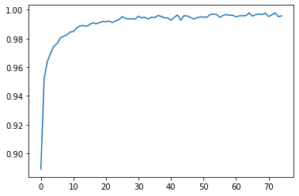

```python
from matplotlib import pyplot

pyplot.plot(h.history['accuracy'])
```

## Stretch Goals:

- Use Hyperparameter Tuning to make the accuracy of your models as high as possible. (error as low as possible)
- Use Cross Validation techniques to get more consistent results with your model.
- Use GridSearchCV to try different combinations of hyperparameters.
- Start looking into other types of Keras layers for CNNs and RNNs maybe try and build a CNN model for fashion-MNIST to see how the results compare.